# B2.324-PEC2-MiguelNicolasRodriguez

Miguel Nicolas Rodriguez

14 de mayo de 2018

# 1

Cargamos los datos en csv

```r
X = read.csv("nbasal.csv", header = TRUE, encoding="UTF-8")
```

# 2 Consulta de datos cargados

## 2.1

Consultar el resumen de la variable wage y el tipo de datos. Como vemos es de tipo numerico

```r
summary(X$wage)
```

```
##    Min. 1st Qu.  Median    Mean 3rd Qu.    Max.
##     150     650    1186    1424    2014    5740
```

```r
str(X$wage)
```

```
##  num [1:269] 1002 2030 650 2030 755 ...
```

## 2.2

Mostrar un boxplot con la distribución de la variable wage

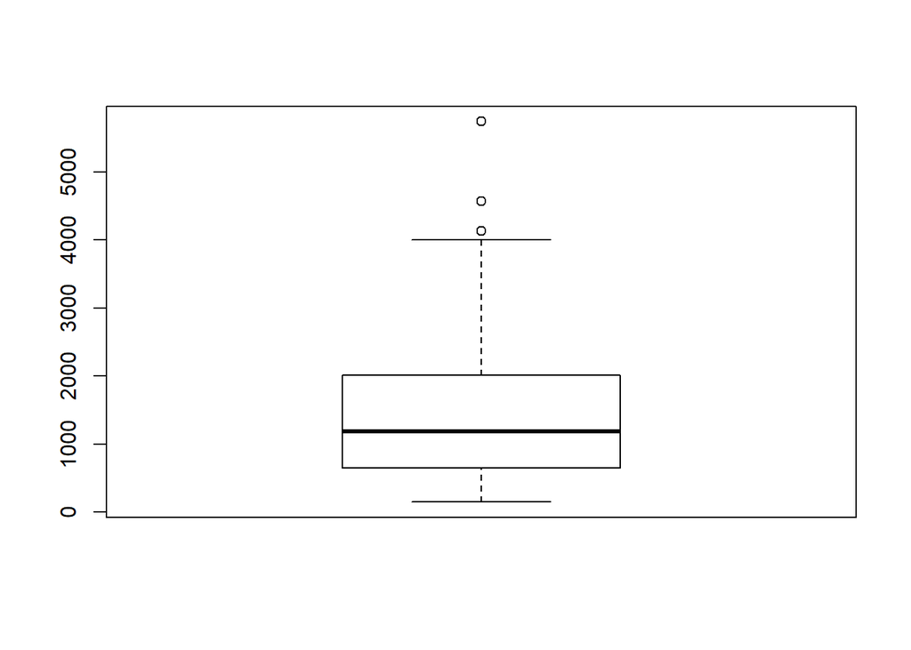

```r
boxplot(X$wage)
```

# 3 Descripción de la muestra

## 3.1

Calcular la media y la desviacion muestral.

```r
mean(X$wage)
```

```
## [1] 1423.828
```

```r
sd(X$wage)
```

```
## [1] 999.7741
```

# 4 Calculamos el intervalo de confianza de salario esperado de un jugador de la NBA a nivel poblacional con un nivel de confianza de 99%

## 4.1 Calcular el intervalo de confianza de 99% de la media poblacional. Suponed que conocéis la desviación estándard de la población (usad la desviación de la muestra) y podéis usar el estadístico z.

```r
media <- mean(X$wage)
desviacion_standard <- sd(X$wage)
alpha <- 1 - 0.99
n <- length(X$wage)

error <- qnorm(1 - alpha /2) * desviacion_standard / sqrt(n)

extremo_izq <- media - error
extremo_der <- media + error

extremo_izq
```

```
## [1] 1266.812
```

```r
extremo_der
```

```
## [1] 1580.843
```

## 4.2. Repetir los cálculos para el estadístico t de Student

```r
alpha <- 1 - 0.99

error <- qt(( 1 - alpha / 2 ),df=n-1) * desviacion_standard/sqrt(n)

extremo_izq_t <- media - error
extremo_der_t <- media + error

extremo_izq_t
```

```
## [1] 1265.686
```

```r
extremo_der_t
```

```
## [1] 1581.969
```

## 4.3. Responder a las siguientes preguntas: ¿Es más estrecho el intervalo de confianza usando la distribución normal o la distribución t de Student? ¿Por qué? ¿Qué intervalo de confianza crees que es el más adecuado con nuestros datos y por qué? Contestar brevemente.

En el caso de la t-student se suele utilizar cuando hay menos de 30 muestras. Al ser la diferencia minima no importa cual utilicemos.

# 5 Análisis de correlaciones ¿Hay correlación lineal entre salario de los jugadores y los puntos medios por partido?

## 5.1. Mostramos un scatter plot con las dos variables: wage y points para ver visualmente si hay correlación lineal.

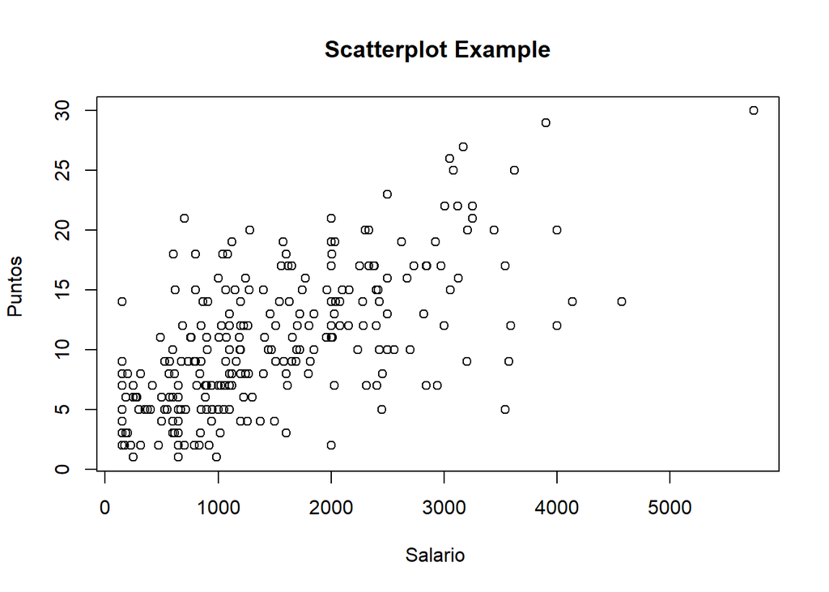

```r
plot(X$wage, X$points, main="Scatterplot Example",
   xlab="Salario ", ylab="Puntos ")
```

## 5.2. Calculamos el coeficiente de correlación lineal entre estas dos variables

```r
cor(X$wage, X$points)
```

```
## [1] 0.6570265
```

## 5.3. Razonar sobre el resultado del coeficiente en relación al valor y al signo (positivo o negativo).

# 6 Regresión: ¿Podemos suponer que las variables de minutos jugados por temporada y puntos medios por partido son unas buenas variables explicativas para poder predecir el comportamiento de la salario de los jugadores de la NBA?

## 6.1. Calculad dos modelos lineales de regresión, donde salario de los jugadores se relaciona con minutos jugados por temporada y puntos medios por partido con constante y sin constante. Usar la función lm de R.

Calculamos con constante y sin constante.

```r
cons_lm <- lm(wage ~ minutes + points, data=X)
sin_lm <- lm(wage ~ 0 + minutes + points, data=X)
```

Mostramos los resultados

```r
cons_lm
```

```
##
## Call:
## lm(formula = wage ~ minutes + points, data = X)
##
## Coefficients:
## (Intercept)      minutes       points
##    261.1353       0.0453     105.8930
```

```r
sin_lm
```

```
##
## Call:
## lm(formula = wage ~ 0 + minutes + points, data = X)
##
## Coefficients:
##  minutes    points
##   0.1348  111.2028
```

## 6.2. Mostrad el resultado de los modelos lineales obtenidos, los coeficientes, etc..

Como vemos en la primera con constante tenemos el intercept y en la segunda no

```r
cons_lm
```

```
##
## Call:
## lm(formula = wage ~ minutes + points, data = X)
##
## Coefficients:
## (Intercept)      minutes       points
##    261.1353       0.0453     105.8930
```

```r
sin_lm
```

```
##
## Call:
## lm(formula = wage ~ 0 + minutes + points, data = X)
##
## Coefficients:
##  minutes    points
##   0.1348  111.2028
```

## 6.3. Estimad el salario que tendría un jugador que anotara 20 puntos en promedio por partido y jugara 2000 minutos por temporada, a partir de los coeficientes del modelo lineal sin constante.

Para ello creamos un nuevo data frame con los parametros del que queremnos predecir

```r
predecir_X <- data.frame(points=c(20),minutes=c(2000))
predict(sin_lm,predecir_X)
```

```
##        1
## 2493.594
```

## 6.4. Mostrad el coeficiente de determinación del modelo lineal e interpretad el coeficiente. Realizad este apartado para los dos modelos lineales obtenidos.

Ahora mostramos el coeficiente de determinacion, usando R_squared

```r
summary(cons_lm)$r.squared
```

```
## [1] 0.4321683
```

```r
summary(sin_lm)$r.squared
```

```
## [1] 0.8081023
```

## 6.5. Al realizar un resumen del modelo lineal, se muestran los valores de los coeficientes y para cada coeficiente un valor Pr(>|t|). ¿A qué se refiere este valor y como se interpreta? Realizar la interpretación para los dos modelos lineales.

Sacamos un summary de los dos modelos

```r
summary(cons_lm)
```

```
##
## Call:
## lm(formula = wage ~ minutes + points, data = X)
##
## Residuals:
##      Min       1Q   Median       3Q      Max
## -1944.94  -459.03   -86.67   408.97  2708.68
##
## Coefficients:
##              Estimate Std. Error t value Pr(>|t|)
## (Intercept) 261.13526   99.42658   2.626  0.00913 **
## minutes       0.04530    0.09509   0.476  0.63419
## points      105.89302   14.44130   7.333 2.72e-12 ***
## ---
## Signif. codes:  0 '***' 0.001 '**' 0.01 '*' 0.05 '.' 0.1 ' ' 1
##
## Residual standard error: 756.2 on 266 degrees of freedom
## Multiple R-squared:  0.4322, Adjusted R-squared:  0.4279
## F-statistic: 101.2 on 2 and 266 DF,  p-value: < 2.2e-16
```

```r
summary(sin_lm)
```

```
##
## Call:
## lm(formula = wage ~ 0 + minutes + points, data = X)
##
## Residuals:
##      Min       1Q   Median       3Q      Max
## -2111.40  -412.75     3.78   438.58  2856.93
##
## Coefficients:
##          Estimate Std. Error t value Pr(>|t|)
## minutes   0.13477    0.08976   1.501    0.134
## points  111.20278   14.45616   7.692 2.79e-13 ***
## ---
## Signif. codes:  0 '***' 0.001 '**' 0.01 '*' 0.05 '.' 0.1 ' ' 1
##
## Residual standard error: 764.5 on 267 degrees of freedom
## Multiple R-squared:  0.8081, Adjusted R-squared:  0.8067
## F-statistic: 562.2 on 2 and 267 DF,  p-value: < 2.2e-16
```